# projectregression

kayvan shabani

8/13/2020

**First I delete NaNs and empty cells to have a complete dataset. Then I split data to Train and Test with 4 to 1 ratio because the more train data one have, one can have better and more accurate model. Additionally, it is better to spend more time on training and spend less time and energy on testing. I chose “Global_Sales” to be the target variable. With summary function one can gain a general idea about attributes.**

```r
library(dplyr)
```

```r
library(ggplot2)
library(regclass)
library(olsrr)
library(sur)
library(fastDummies)
library(MASS)
library(car)
library(glmnet)
library(purrr)
library(caTools)

set.seed(100)
setwd("/Users/kayvanshabani/Documents/educational/Regression/project/regression/")
videogames = read.csv("Video_Games_Sales_as_at_22_Dec_2016.csv")
videogames = na.omit(videogames)
videogames = filter(videogames, videogames$Year_of_Release != "N/A")
videogames = filter(videogames, Rating != "")

vgsample = sample.split(videogames, SplitRatio = 0.8)
videogames_train = subset(videogames, vgsample == TRUE)
videogames_test = subset(videogames, vgsample == FALSE)
target = "Global_Sales"

sapply(videogames_train[,-10], summary)
```

```
## $Name
##    Length     Class      Mode
##      5121 character character
##
## $Platform
##    Length     Class      Mode
##      5121 character character
##
## $Year_of_Release
##    Length     Class      Mode
##      5121 character character
##
## $Genre
##    Length     Class      Mode
##      5121 character character
##
## $Publisher
##    Length     Class      Mode
##      5121 character character
##
## $NA_Sales
##    Min. 1st Qu.  Median    Mean 3rd Qu.    Max.
##  0.0000  0.0600  0.1500  0.4005  0.3900 41.3600
##
## $EU_Sales
##    Min. 1st Qu.  Median    Mean 3rd Qu.    Max.
##  0.0000  0.0200  0.0600  0.2392  0.2100 28.9600
##
## $JP_Sales
##    Min. 1st Qu.  Median    Mean 3rd Qu.    Max.
## 0.00000 0.00000 0.00000 0.06582 0.01000 6.50000
##
## $Other_Sales
##    Min. 1st Qu.  Median    Mean 3rd Qu.    Max.
## 0.00000 0.01000 0.02000 0.08093 0.07000 8.45000
##
## $Critic_Score
##    Min. 1st Qu.  Median    Mean 3rd Qu.    Max.
##   13.00   62.00   72.00   70.13   80.00   98.00
##
## $Critic_Count
##    Min. 1st Qu.  Median    Mean 3rd Qu.    Max.
##    3.00   14.00   24.00   28.96   39.00  113.00
##
## $User_Score
##    Length     Class      Mode
##      5121 character character
##
## $User_Count
##    Min. 1st Qu.  Median    Mean 3rd Qu.    Max.
##     4.0    11.0    27.0   177.1    89.0 10665.0
##
## $Developer
##    Length     Class      Mode
##      5121 character character
##
## $Rating
##    Length     Class      Mode
##      5121 character character
```

**I use ggplot2 to draw point plots and boxplots between attributes and target to gain a better insight from dataset.**

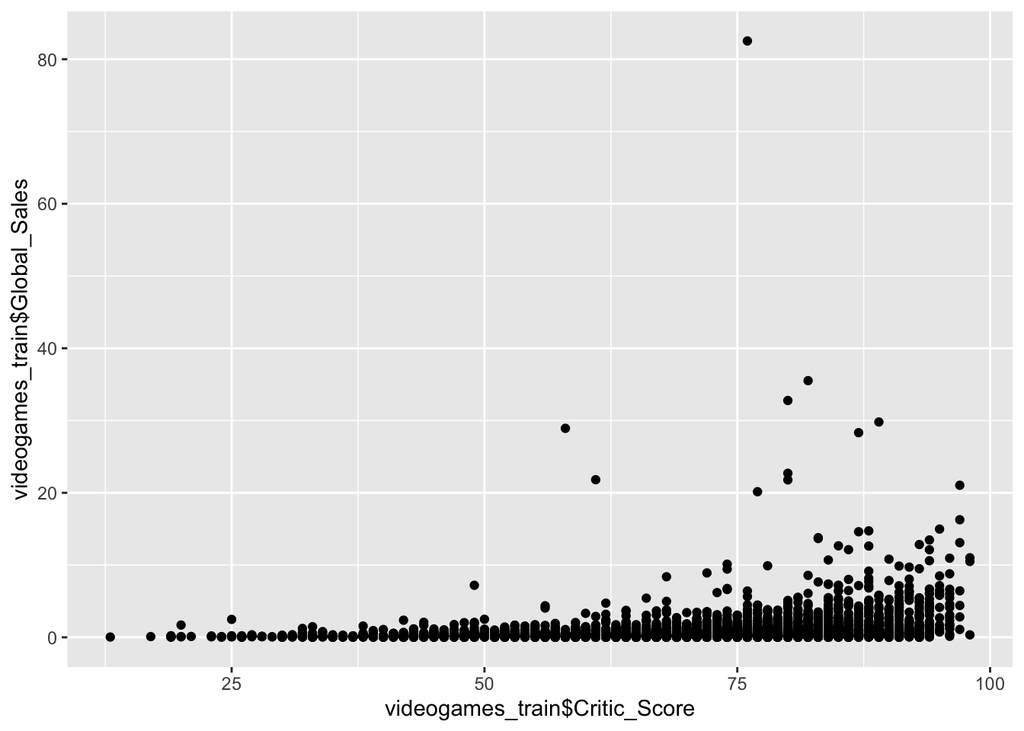

```r
ggplot(videogames_train, aes(videogames_train$Critic_Score, videogames_train$Global_Sales)) + geom_point()
```

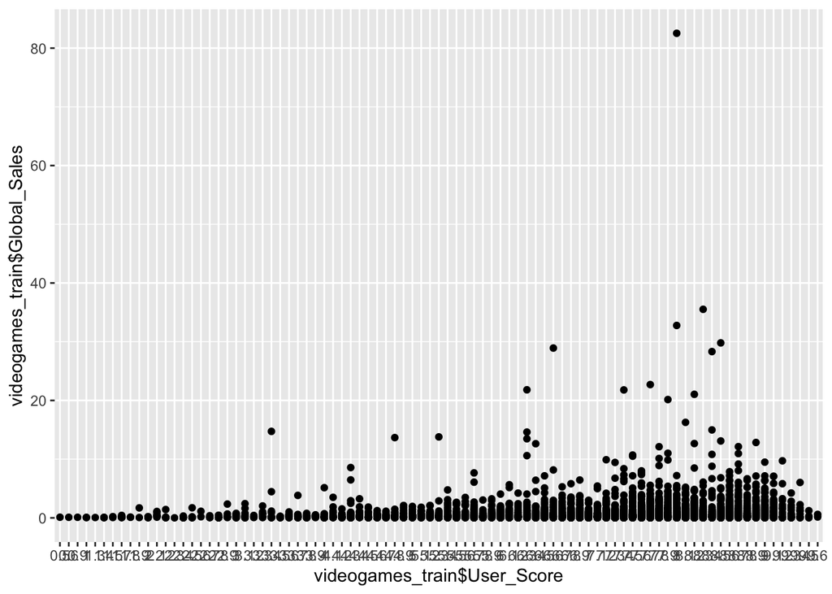

```r
ggplot(videogames_train, aes(videogames_train$User_Score, videogames_train$Global_Sales)) + geom_point()
```

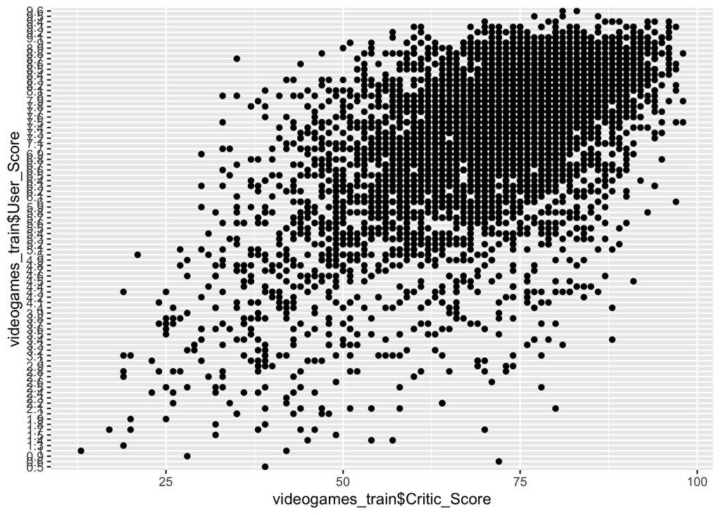

```r
ggplot(videogames_train, aes(videogames_train$Critic_Score, videogames_train$User_Score)) + geom_point()
```

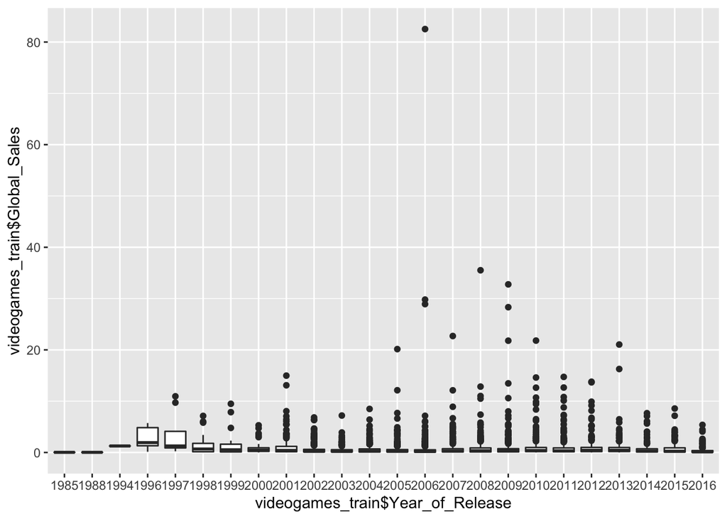

```r
ggplot(videogames_train, aes(videogames_train$Year_of_Release, videogames_train$Global_Sales)) + geom_boxplot()
```

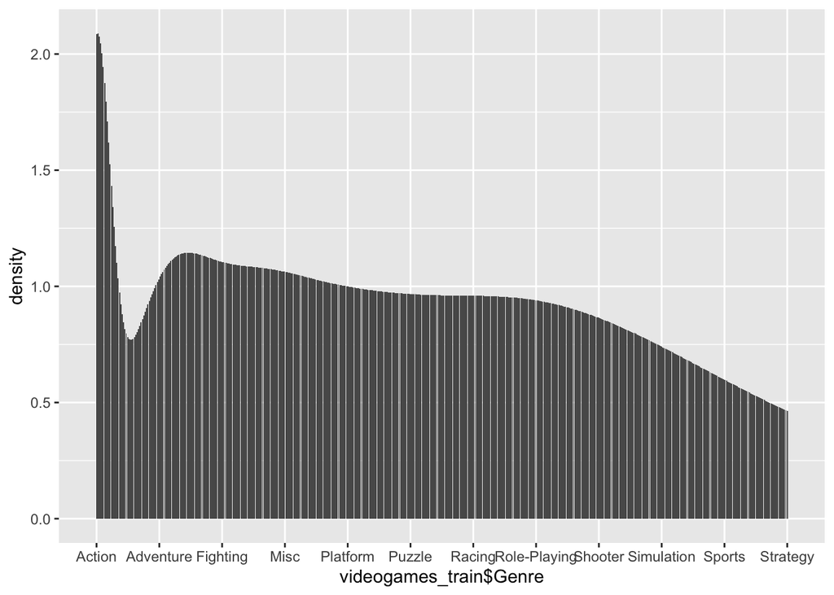

```r
ggplot(videogames_train, aes(videogames_train$Genre)) + geom_histogram(stat = "density")
```

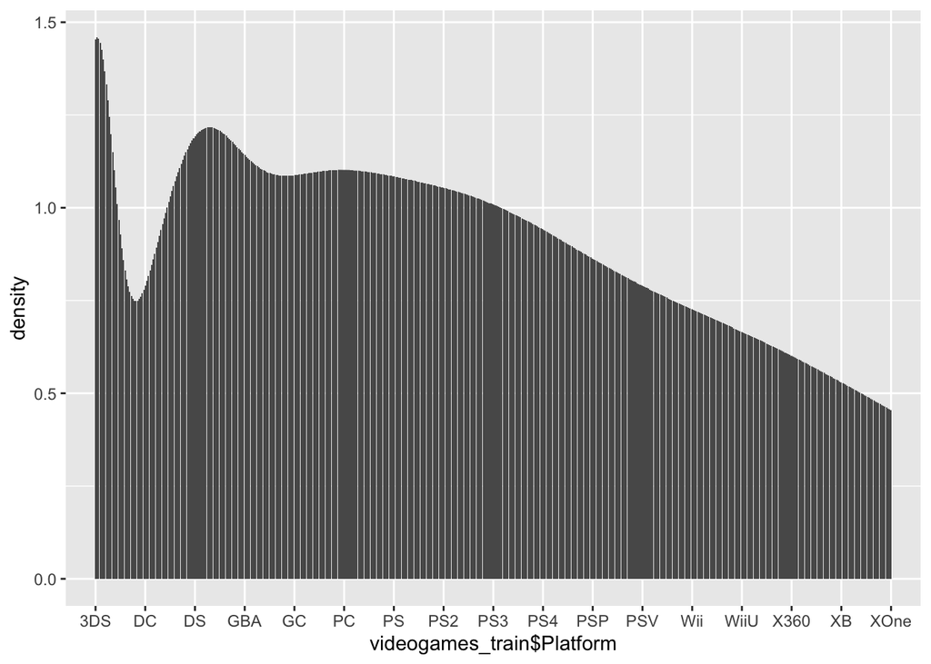

```r
ggplot(videogames_train, aes(videogames_train$Platform)) + geom_histogram(stat = "density")
```

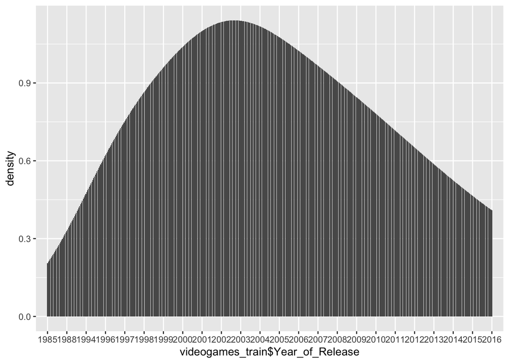

```r
ggplot(videogames_train, aes(videogames_train$Year_of_Release)) + geom_histogram(stat = "density")
```

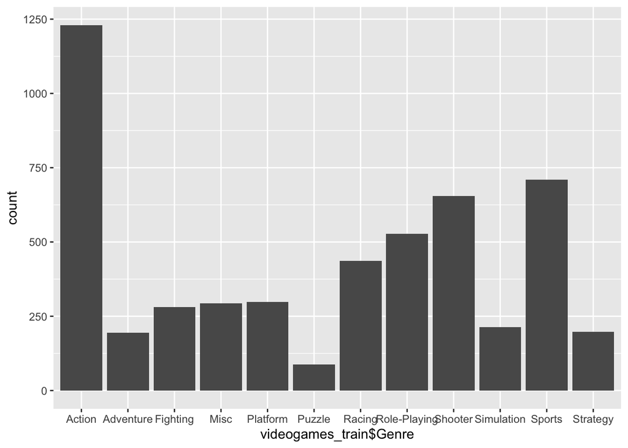

```r
ggplot(videogames_train, aes(videogames_train$Genre)) + geom_histogram(stat = "count")
```

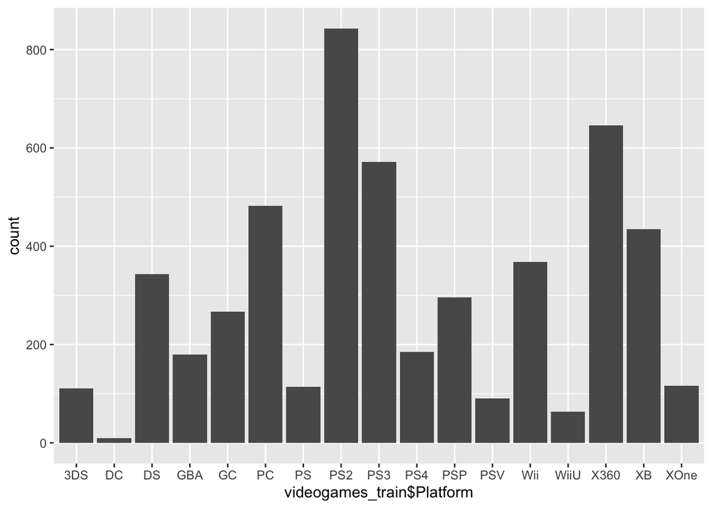

```r
ggplot(videogames_train, aes(videogames_train$Platform)) + geom_histogram(stat = "count")
```

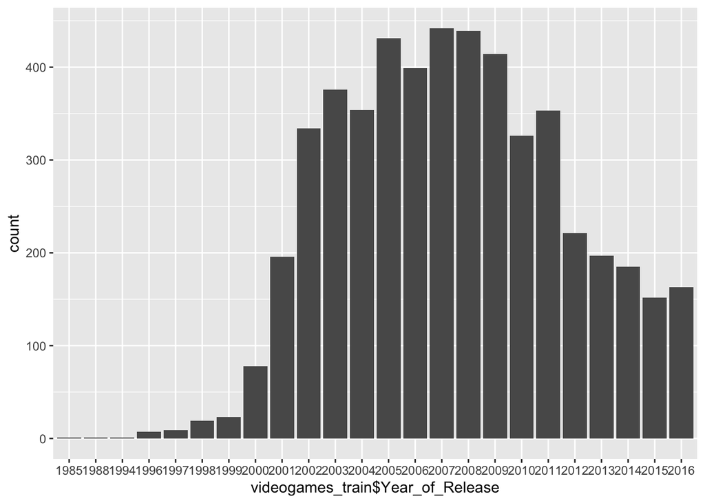

```r
ggplot(videogames_train, aes(videogames_train$Year_of_Release)) + geom_histogram(stat = "count")
```

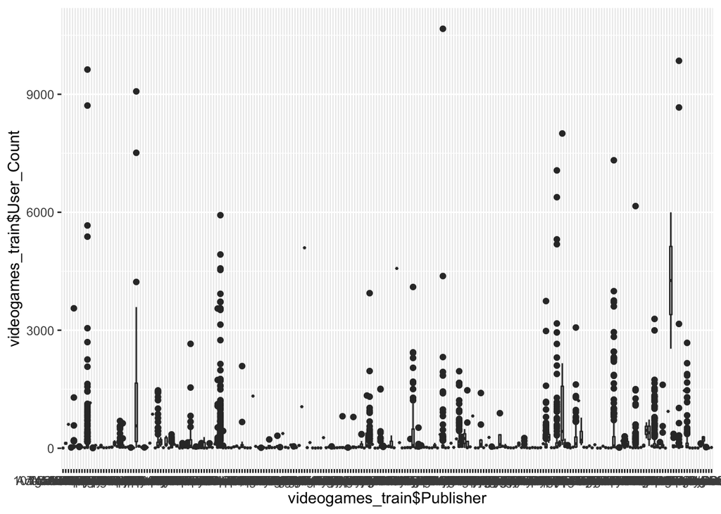

```r
ggplot(videogames_train, aes(videogames_train$Publisher, videogames_train$User_Count)) + geom_boxplot()
```

Now, I convert qualitative variables to dummies which ables me to do the regression. If I do not do the conversion, I should give a number to each category. In this way some categories gain more score than others, which is not true because all of the categories have the same level of importance. Hence, I assume one dummy variable for each category. 0 means sample is not in that category and 1 means sample is in that category.  
Also, because target is Global Sales, I will not consider countries’ sales as attributes because they are part of Global Sales and in a way they are same as target, so they should not be considered as attributes. If we use them R squared will be large. However, it is not necessarily good because they are part of the target variable.  
Additionally, some columns have number values but their type is character in dataset, so I convert them to numbers.

```r
newvidtr = dummy_cols(videogames_train, select_columns = c('Platform','Genre','Publisher','Developer' ,'Rating'))
newvidte = dummy_cols(videogames_test, select_columns = c('Platform','Genre','Publisher','Developer' ,'Rating'))
videogames_train = newvidtr[,-c(2,4:9,15,16)]
videogames_test = newvidte[,-c(2,4:9,15,16)]
videogames_train$Year_of_Release = as.numeric(videogames_train$Year_of_Release)
videogames_train$User_Score = as.double(videogames_train$User_Score)
videogames_test$Year_of_Release = as.numeric(videogames_test$Year_of_Release)
videogames_test$User_Score = as.double(videogames_test$User_Score)
```

**In this step, I calculate PCA and see that from 1423 dimensions, cumulative variance became 90 percent after 1087, and got to 95 percent after 1159. Hence, if i use forward or backward or best subset algorithms, I can not reduce a lot of dimensions. Therefore, I fit the regression model with all of the features and will delete the ones with large pvalue.**

```r
videopca = prcomp(videogames_train[,-c(1,3)], center = TRUE, scale. = TRUE)
summary(videopca)$importance[3,]
```

[output not shown]

[output cut: 231 more lines]

[output not shown]

**Because I am going to use VIF to check collinearity and this function will not run unless variables which have complete collinearity do not exist in the model, I first make a model without these variables.**

```r
firstlin = lm(Global_Sales~.-(Global_Sales+Name), videogames_train)
ldvars = rownames(alias(firstlin)$Complete)
firstformula = as.formula(paste("Global_Sales~.-(Global_Sales+Name+", paste(ldvars, collapse = "+"), ")"))
firstlin.new = lm(firstformula, videogames_train)
```

**Then I choose variable that have pvalues lower than 0.05 (26 variables) and make another model with them.**

```r
newvars = rownames(summary(firstlin.new)$coefficients[summary(firstlin.new)$coefficients[,4]<0.05,])
secondformula = as.formula(paste("Global_Sales~", paste(newvars[-1], collapse = "+")))
secondlin = lm(secondformula, videogames_train)
summary(secondlin)
```

```
##
## Call:
## lm(formula = secondformula, data = videogames_train)
##
## Residuals:
##    Min     1Q Median     3Q    Max
## -8.087 -0.511 -0.147  0.250 72.816
##
## Coefficients:
##                                                                            Estimate
## (Intercept)                                                               5.210e+01
## Year_of_Release                                                          -2.651e-02
## Critic_Score                                                              1.620e-02
## Critic_Count                                                              1.411e-02
## User_Count                                                                6.507e-04
## Platform_GBA                                                             -3.587e-01
## Platform_GC                                                              -4.943e-01
## Platform_PC                                                              -8.889e-01
## Platform_Wii                                                              7.401e-01
## Platform_WiiU                                                            -7.987e-01
## Genre_Action                                                              1.745e-01
## Genre_Fighting                                                            2.075e-01
## Genre_Misc                                                                5.092e-01
## Genre_Platform                                                            2.921e-01
## Genre_Racing                                                              2.639e-01
## Genre_Shooter                                                             2.159e-01
## Genre_Simulation                                                          3.728e-01
## Genre_Sports                                                              4.447e-01
## Developer_Bungie                                                          6.611e+00
## `Developer_DMA Design`                                                    6.898e+00
## `Developer_Good Science Studio`                                           2.080e+01
## Developer_Nintendo                                                        7.459e+00
## `Developer_Polyphony Digital`                                             8.146e+00
## `Developer_Retro Studios, Entertainment Analysis & Development Division`  1.080e+01
## `Developer_Rockstar North`                                                5.095e+00
## Rating_AO                                                                -4.657e+00
## Rating_M                                                                  2.754e-02
##                                                                          Std. Error
## (Intercept)                                                               1.272e+01
## Year_of_Release                                                           6.334e-03
```

[output cut: 100 more lines]

```
## Developer_Bungie                                                         ***
## `Developer_DMA Design`                                                   ***
## `Developer_Good Science Studio`                                          ***
## Developer_Nintendo                                                       ***
## `Developer_Polyphony Digital`                                            ***
## `Developer_Retro Studios, Entertainment Analysis & Development Division` ***
## `Developer_Rockstar North`                                               ***
## Rating_AO                                                                *
## Rating_M
## ---
## Signif. codes:  0 '***' 0.001 '**' 0.01 '*' 0.05 '.' 0.1 ' ' 1
##
## Residual standard error: 1.714 on 5094 degrees of freedom
## Multiple R-squared:  0.3297, Adjusted R-squared:  0.3263
## F-statistic: 96.36 on 26 and 5094 DF,  p-value: < 2.2e-16
```

**Now I run PCA with this 26 variables and see that cumulative variance proportion got to 90 percent after 21st dimension.**

```r
newvarspca = gsub("\\`","",newvars)
videopca2 = prcomp(videogames_train[,c(newvarspca[-1])], center = TRUE, scale. = TRUE)
summary(videopca2)
```

```
## Importance of components:
##                            PC1    PC2     PC3     PC4     PC5     PC6     PC7
## Standard deviation     1.52909 1.2248 1.17452 1.16126 1.12837 1.10384 1.08698
## Proportion of Variance 0.08993 0.0577 0.05306 0.05187 0.04897 0.04686 0.04544
## Cumulative Proportion  0.08993 0.1476 0.20069 0.25255 0.30152 0.34839 0.39383
##                            PC8     PC9    PC10    PC11    PC12    PC13    PC14
## Standard deviation     1.08398 1.03572 1.02065 1.01018 1.00810 1.00030 0.99599
## Proportion of Variance 0.04519 0.04126 0.04007 0.03925 0.03909 0.03848 0.03815
## Cumulative Proportion  0.43902 0.48028 0.52035 0.55960 0.59868 0.63717 0.67532
##                           PC15    PC16    PC17    PC18    PC19    PC20    PC21
## Standard deviation     0.98989 0.97912 0.96951 0.95888 0.92354 0.86479 0.82308
## Proportion of Variance 0.03769 0.03687 0.03615 0.03536 0.03281 0.02876 0.02606
## Cumulative Proportion  0.71301 0.74988 0.78603 0.82140 0.85420 0.88297 0.90902
##                          PC22    PC23    PC24   PC25    PC26
## Standard deviation     0.8014 0.75185 0.71951 0.6469 0.47082
## Proportion of Variance 0.0247 0.02174 0.01991 0.0161 0.00853
## Cumulative Proportion  0.9337 0.95547 0.97538 0.9915 1.00000
```

**Now I can use forward algorithm to choose these dimensions because it seems like that dataset can perform well on 21 dimensions. I cannot use best subset algorithm because of memory and time problems. Also, I could use backward algorithm.**

```r
frwrd = ols_step_forward_p(secondlin)
newvars2 = frwrd$predictors[1:21]
```

**Then I train a model with these 21 variables and calculate VIF. All of the values in VIF are in the normal range and there are no collinearity. In my last model 2 of the variables had pvalues greater than 0.05. I omit them from the model and train a model with 19 left variables.**

```r
thirdformula = as.formula(paste("Global_Sales~", paste(newvars2, collapse = "+")))
thirdlin = lm(thirdformula, videogames_train)
summary(thirdlin)
```

```
##
## Call:
## lm(formula = thirdformula, data = videogames_train)
##
## Residuals:
##    Min     1Q Median     3Q    Max
## -8.011 -0.505 -0.159  0.248 72.830
##
## Coefficients:
##                                                                            Estimate
## (Intercept)                                                               5.253e+01
## Developer_Nintendo                                                        7.437e+00
## Critic_Count                                                              1.443e-02
## User_Count                                                                6.524e-04
## `Developer_Good Science Studio`                                           2.079e+01
## `Developer_Polyphony Digital`                                             8.253e+00
## Platform_PC                                                              -9.101e-01
## Critic_Score                                                              1.583e-02
## Platform_Wii                                                              7.377e-01
## `Developer_Rockstar North`                                                5.145e+00
## `Developer_Retro Studios, Entertainment Analysis & Development Division`  1.090e+01
## `Developer_DMA Design`                                                    6.932e+00
## Platform_WiiU                                                            -7.942e-01
## Developer_Bungie                                                          6.681e+00
## Genre_Sports                                                              2.931e-01
## Platform_GC                                                              -4.906e-01
## Year_of_Release                                                          -2.664e-02
## Genre_Misc                                                                3.553e-01
## Platform_GBA                                                             -3.677e-01
## Rating_AO                                                                -4.690e+00
## Genre_Simulation                                                          2.250e-01
## Genre_Platform                                                            1.391e-01
##                                                                          Std. Error
## (Intercept)                                                               1.264e+01
## Developer_Nintendo                                                        2.477e-01
## Critic_Count                                                              1.513e-03
## User_Count                                                                4.564e-05
## `Developer_Good Science Studio`                                           1.718e+00
## `Developer_Polyphony Digital`                                             7.691e-01
## Platform_PC                                                               9.022e-02
```

[output cut: 75 more lines]

```
## Developer_Bungie                                                         ***
## Genre_Sports                                                             ***
## Platform_GC                                                              ***
## Year_of_Release                                                          ***
## Genre_Misc                                                               ***
## Platform_GBA                                                             **
## Rating_AO                                                                *
## Genre_Simulation                                                         .
## Genre_Platform
## ---
## Signif. codes:  0 '***' 0.001 '**' 0.01 '*' 0.05 '.' 0.1 ' ' 1
##
## Residual standard error: 1.715 on 5099 degrees of freedom
## Multiple R-squared:  0.3282, Adjusted R-squared:  0.3254
## F-statistic: 118.6 on 21 and 5099 DF,  p-value: < 2.2e-16
```

```r
vif(thirdlin)
```

```
##                                                       Developer_Nintendo
##                                                                 1.053095
##                                                             Critic_Count
##                                                                 1.482435
##                                                               User_Count
##                                                                 1.348883
##                                          `Developer_Good Science Studio`
##                                                                 1.003800
##                                            `Developer_Polyphony Digital`
##                                                                 1.004374
##                                                              Platform_PC
##                                                                 1.208286
##                                                             Critic_Score
##                                                                 1.318998
##                                                             Platform_Wii
##                                                                 1.057379
##                                               `Developer_Rockstar North`
##                                                                 1.155183
## `Developer_Retro Studios, Entertainment Analysis & Development Division`
##                                                                 1.001169
##                                                   `Developer_DMA Design`
##                                                                 1.002548
##                                                            Platform_WiiU
##                                                                 1.054818
##                                                         Developer_Bungie
##                                                                 1.003625
##                                                             Genre_Sports
##                                                                 1.111818
##                                                              Platform_GC
##                                                                 1.087025
##                                                          Year_of_Release
##                                                                 1.221140
##                                                               Genre_Misc
##                                                                 1.050378
##                                                             Platform_GBA
##                                                                 1.088706
##                                                                Rating_AO
##                                                                 1.128780
##                                                         Genre_Simulation
##                                                                 1.042544
##                                                           Genre_Platform
##                                                                 1.050257
```

```r
finalvars = newvars2[1:19]
fourthformula = as.formula(paste("Global_Sales~", paste(finalvars, collapse = "+")))
fourthlin = lm(fourthformula, videogames_train)
summary(fourthlin)
```

```
##
## Call:
## lm(formula = fourthformula, data = videogames_train)
##
## Residuals:
##    Min     1Q Median     3Q    Max
## -8.054 -0.503 -0.162  0.258 72.800
##
## Coefficients:
##                                                                            Estimate
## (Intercept)                                                              54.1526170
## Developer_Nintendo                                                        7.4671523
## Critic_Count                                                              0.0142122
## User_Count                                                                0.0006486
## `Developer_Good Science Studio`                                          20.8045400
## `Developer_Polyphony Digital`                                             8.2345060
## Platform_PC                                                              -0.8956011
## Critic_Score                                                              0.0159620
## Platform_Wii                                                              0.7453523
## `Developer_Rockstar North`                                                5.1327298
## `Developer_Retro Studios, Entertainment Analysis & Development Division` 10.8922154
## `Developer_DMA Design`                                                    6.9063552
## Platform_WiiU                                                            -0.7781735
## Developer_Bungie                                                          6.6830761
## Genre_Sports                                                              0.2694943
## Platform_GC                                                              -0.4898524
## Year_of_Release                                                          -0.0274436
## Genre_Misc                                                                0.3324006
## Platform_GBA                                                             -0.3569941
## Rating_AO                                                                -4.6963318
##                                                                          Std. Error
## (Intercept)                                                              12.6189293
## Developer_Nintendo                                                        0.2472290
## Critic_Count                                                              0.0015097
## User_Count                                                                0.0000456
## `Developer_Good Science Studio`                                           1.7189614
## `Developer_Polyphony Digital`                                             0.7692136
## Platform_PC                                                               0.0894913
## Critic_Score                                                              0.0019617
## Platform_Wii                                                              0.0953841
```

[output cut: 65 more lines]

```
## `Developer_DMA Design`                                                   ***
## Platform_WiiU                                                            ***
## Developer_Bungie                                                         ***
## Genre_Sports                                                             ***
## Platform_GC                                                              ***
## Year_of_Release                                                          ***
## Genre_Misc                                                               **
## Platform_GBA                                                             **
## Rating_AO                                                                *
## ---
## Signif. codes:  0 '***' 0.001 '**' 0.01 '*' 0.05 '.' 0.1 ' ' 1
##
## Residual standard error: 1.716 on 5101 degrees of freedom
## Multiple R-squared:  0.3275, Adjusted R-squared:  0.325
## F-statistic: 130.8 on 19 and 5101 DF,  p-value: < 2.2e-16
```

Now I will identify samples which are outlier or have high leverage and delete them from dataset. First, I draw plots for my last model. From residual vs leverage plot it can be seen that some samples have long distance from others on horizontal axis and from normal value((p+1)/n). These are the high leverage samples. I detect them and delete the from the dataset. Also, there are samples which have standardized residual values below -3 or greater than 3. These are outliers. I detect and omit them from the dataset.  
Then I put remaining samples with their attributes on a new table. Then I draw boxplots from attributes of this table to make sure I did not miss any high leverage or outlier.

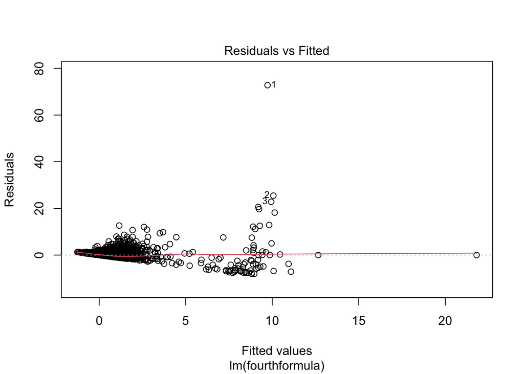

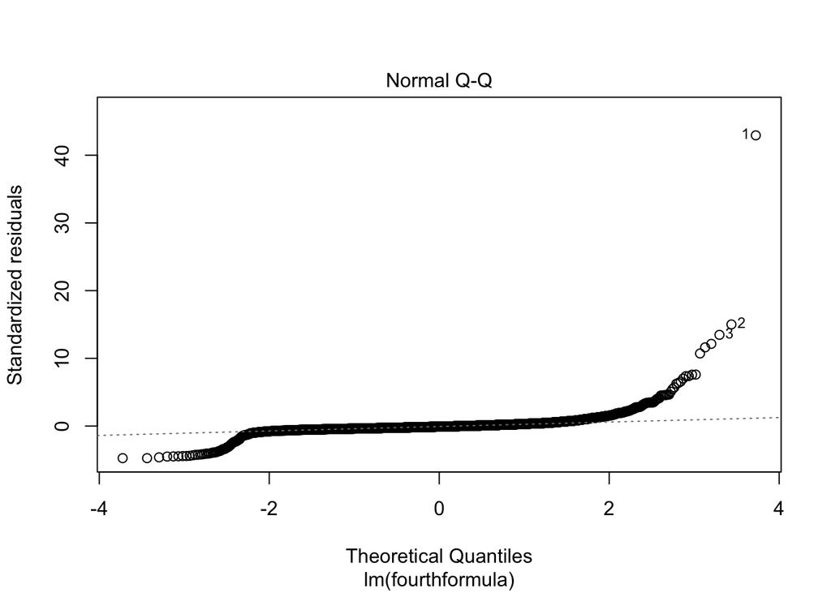

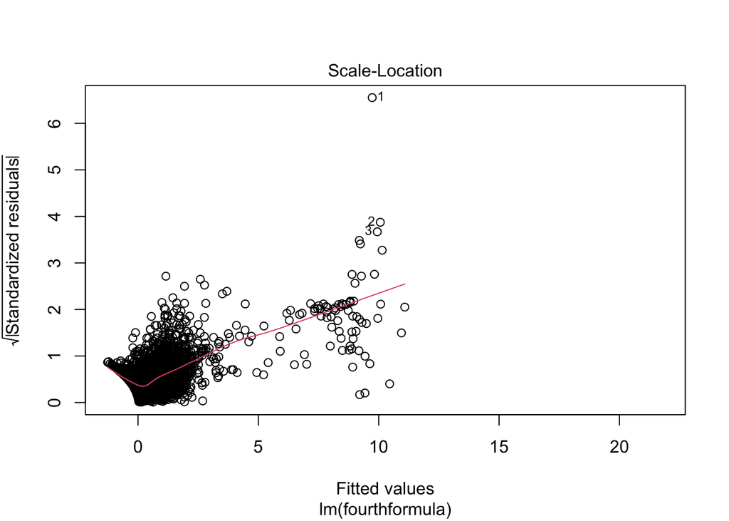

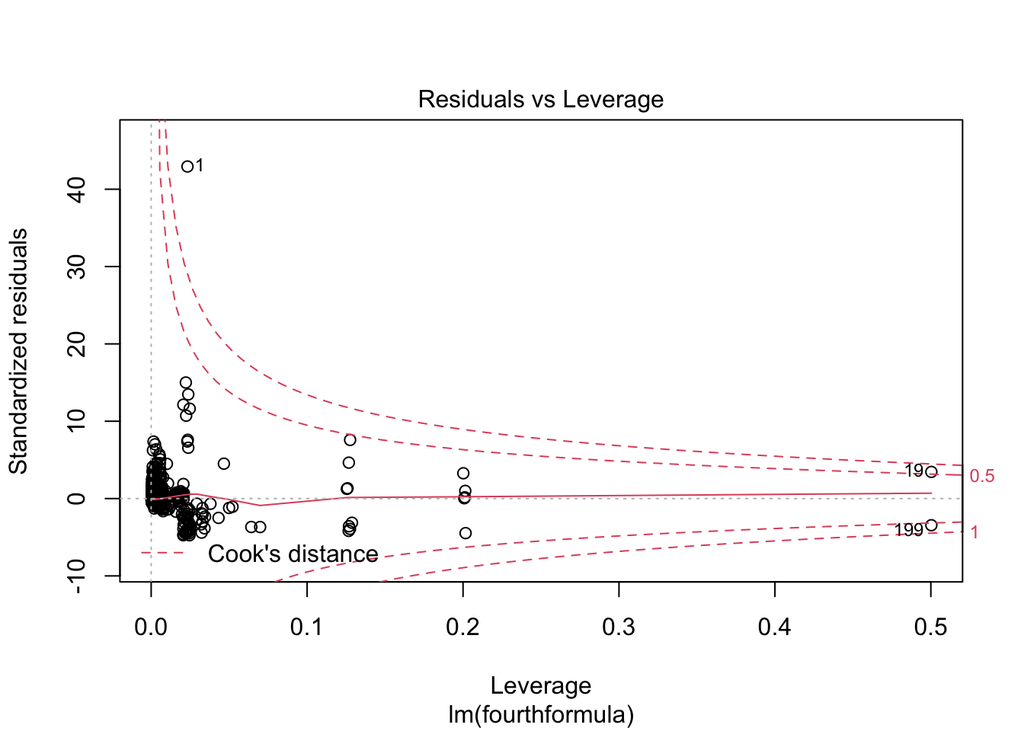

```r
plot(fourthlin)
```

```r
levs = leverage(fourthlin)
levsdf = data.frame(
  x1 = levs,
  x2 = 0
)
colnames(levsdf) = c("x1", "x2")

highlevs = as.numeric(row.names(levsdf[levsdf$x1 > 0.1, ]))
stdrs = stdres(fourthlin)
lowstdrs = as.numeric(names(stdrs[stdrs < -3]))
highstdrs = as.numeric(names(stdrs[stdrs > 3]))
outliers = union(union(highlevs, highstdrs), lowstdrs)
videogames_train2 = videogames_train[-c(outliers),c(gsub("\\`","",finalvars), "Global_Sales")]
finalvars
```

```
##  [1] "Developer_Nintendo"
##  [2] "Critic_Count"
##  [3] "User_Count"
##  [4] "`Developer_Good Science Studio`"
##  [5] "`Developer_Polyphony Digital`"
##  [6] "Platform_PC"
##  [7] "Critic_Score"
##  [8] "Platform_Wii"
##  [9] "`Developer_Rockstar North`"
## [10] "`Developer_Retro Studios, Entertainment Analysis & Development Division`"
## [11] "`Developer_DMA Design`"
## [12] "Platform_WiiU"
## [13] "Developer_Bungie"
## [14] "Genre_Sports"
## [15] "Platform_GC"
## [16] "Year_of_Release"
## [17] "Genre_Misc"
## [18] "Platform_GBA"
## [19] "Rating_AO"
```

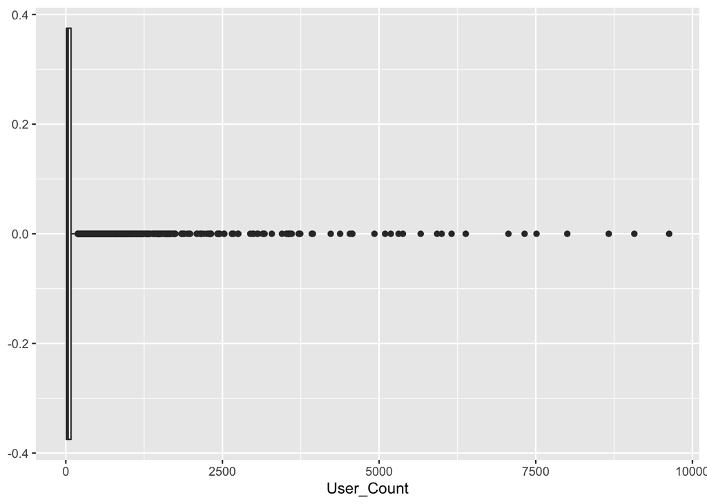

```r
ggplot(videogames_train2, aes(User_Count)) + geom_boxplot()
```

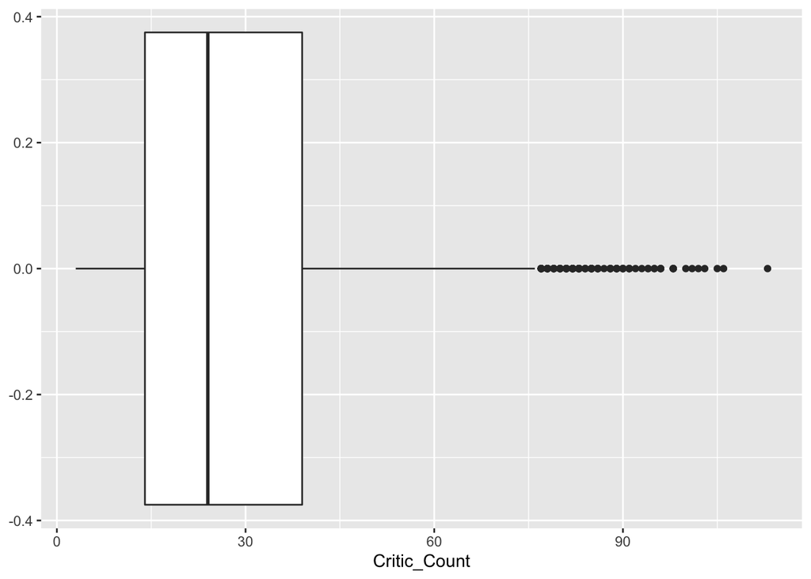

```r
ggplot(videogames_train2, aes(Critic_Count)) + geom_boxplot()
```

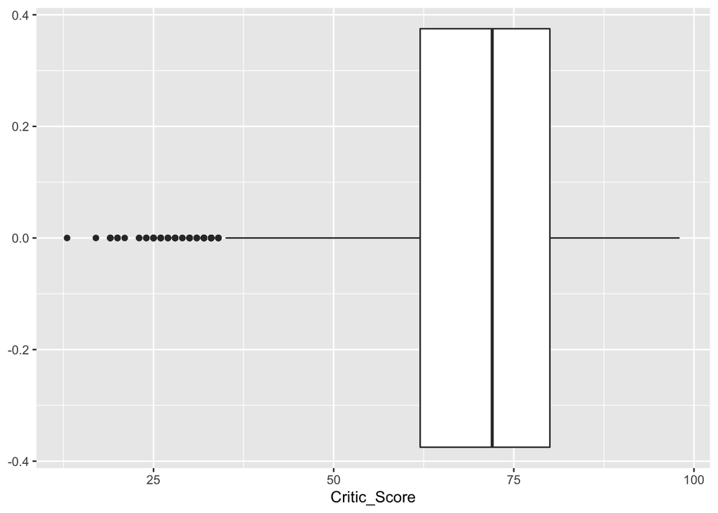

```r
ggplot(videogames_train2, aes(Critic_Score)) + geom_boxplot()
```